# Informe ¿En que época del año se es más vulnerable a un ataque informático?

Daniel Malvarez, Miquel Fairman, Carolina Recalde

08 de junio 2018

## Introducción

Un ataque informático es uno de los eventos mas preocupantes que puede surgir en un entorno empresarial, por ello el área de seguridad de una empresa debe estar al corriente tanto de los posibles parches como incidentes se han suscitado en otras compañías o servicios atacados.

Es inverosímil creer que un ataque se llevara a cabo en un lugar y hora exacta de acuerdo a un estándar predeterminado, pero si se puede tener una estadística que muestre cuando estar mas al pendiente de cualquier posible incidente.

En la actualidad, gracias a varias organizaciones se preocupan por recoger datos y publicarlos, podemos ver una tendencia, no solo en cuanto a ataques informáticos sino también a cve´s (common vulnerabilities and exposures) y breaches, esto lo han hecho a través de los años y nos proporcionan datos que pueden ser de mucha utilidad para determinar cierto patrón que utilizan los hackers para atacar.

Para la elaboración de este documento se han tomado bases de datos de diferentes páginas web, a priori se ha obtenido información de cve´s, breaches e incidentes que se han reportado en el transcurso de los años, en diferentes fuentes de información, esto ha ayudado a realizar los grafos que se explicaran en el desarrollo del mismo.

## Desarrollo

Primero se ha revisado que tan afectados han sido los distintos paises por incidentes en el 2017 dentro de la base de datos en la que se trabajo, esto se puede presenciar en la siguiente gráfica donde se muestra que mientras más rojo se torne un país, ha tenido mayor cantidad de incidentes y mientras más tienda a amarillo el mismo es porque menos incidentes se han dado, como se menciono esta es una base de datos pública, existen otras que son privadas y pueden tener variables en los datos presentados, cabe mencionar que esta base de datos se ha realizado tan solo con los incidentes proporcionados por las personas afectadas y que puede haber muchos más con los que no cuenta, pero esto muestra resultados de la magnitu de incidentes que hoy en día se suscitan.

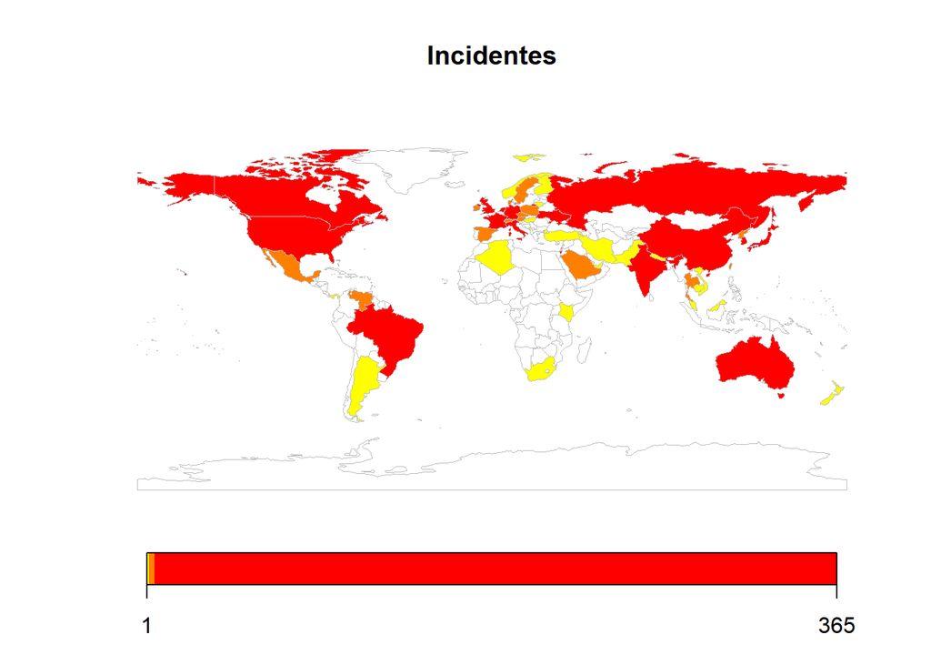

Para el análisis realizado se obtuvieron datos de distintas fuentes, entre ellas: -Hackmagedon: nos brindó datos relacionados con ataques informáticos ocurridos en los últimos años. Enlace -BeautifulInfo: es un sitio web del cual pudimos conseguir datos históricos de Breaches publicados. Enlace -Librería “Net.Security”" es una librería que nos fue introducida en clases de la cuál pudimos obtener datos de cves históricos. Enlace

En la fase de exploración de proyecto realizamos un tratamiento especial sobre los campos tipo fecha ya que consideramos que esta información es necesario disponerla de la manera mas flexible para encontrar resultados de acuerdo a la pregunta planteada al inicio del trabajo. Es por eso que se creó una función que nos permita a partir de un dataframe con un campo tipo date obtener otro dataframe con las filas del primero añadidas y con 5 columnas adicionales que indiquen AÑO,MES,DIA (del mes),DIA JULIANO (del año) y Categoría. Esta función nos permite tomar distintas fuentes de datos y unificarlas de acuerdo al campo fecha que todos los eventos poseen en común, manteniendo siempre la identificación de la fuente a través del campo “Categoría” agregado.

Como parte del tratamiento de datos decidimos que sería conveniente hacer un conteo unificado de los eventos de las distintas fuentes de datos, es por eso que aprovechando nuestro dataframe principal obtuvimos información como por ejemplo cantidad de ataques, cves y breaches publicados en el período 2012-2017:

| Categoria | Total |
| --- | --- |
| attacks | 951 |
| breaches | 115 |
| cves | 49908 |

Como podemos observar, la cantidad de observaciones entre distintas categorías son muy dispares, Es por esto que decidimos normalizar los datos para obtener información que realmente sea de valor. Entonces decidimos realizar otra vista que nos permita observar para cada categoría el número de ocurrencias por cada mes del año y luego con esto lograr obtener porcentajes de ocurrencias por mes respecto al total de cada categoría. Obteniendo una tabla como la siguiente:

| Mes | % Ataques | % Breaches | % CVEs |
| --- | --- | --- | --- |
| 01 | 9.463722 | 8.695652 | 7.786327 |
| 02 | 7.991588 | 16.521739 | 6.327643 |
| 03 | 6.834911 | 5.217391 | 7.119099 |
| 04 | 8.937960 | 5.217391 | 8.343352 |
| 05 | 7.045216 | 12.173913 | 13.096097 |
| 06 | 6.729758 | 6.086957 | 6.580107 |
| 07 | 7.255521 | 12.173913 | 8.706019 |
| 08 | 9.463722 | 5.217391 | 8.269215 |
| 09 | 7.991588 | 5.217391 | 9.245011 |
| 10 | 9.884332 | 6.086957 | 10.948145 |
| 11 | 8.832808 | 10.434783 | 6.375731 |
| 12 | 9.568875 | 6.956522 | 7.203254 |

## Resultados

En base al tratamiento hecho de los datos obtenidos decidimos generar algunas gráficas que nos aporten un valor agregado para la elaboración de conlusiones finales respecto al objetivo planteado.

[interactive chart not shown]

El año 2017, el ultimo año completo a la fecha, nos a arrojado la grafica siguiente, donde podemos observar que no hay una tendencia especifica para un ataque pero si que hay un incremento en meses del año esperado, como lo son vacaciones de verano donde se ve que en meses de julio un incremento tanto de cves como de ataques, diciembre y enero de igual manera son meses a tener en cuenta ya que son los meses donde más flujo de dinero se mueve por festividades como navidad y año nuevo, donde si se refleja un incremento de ataques pero al ser meses laboralmente no muy regulares por las festividades se ve un decremento en el porcentaje de los cves.

Por ultimo en meses de marzo y abril hay otro feriado que hay que tener en consideración y es semana santa donde tambien se muestra un incremento de ataques mientras que cves despunta anormamente y puede darse a una tendencia exclusiva de ese año.

[interactive chart not shown]

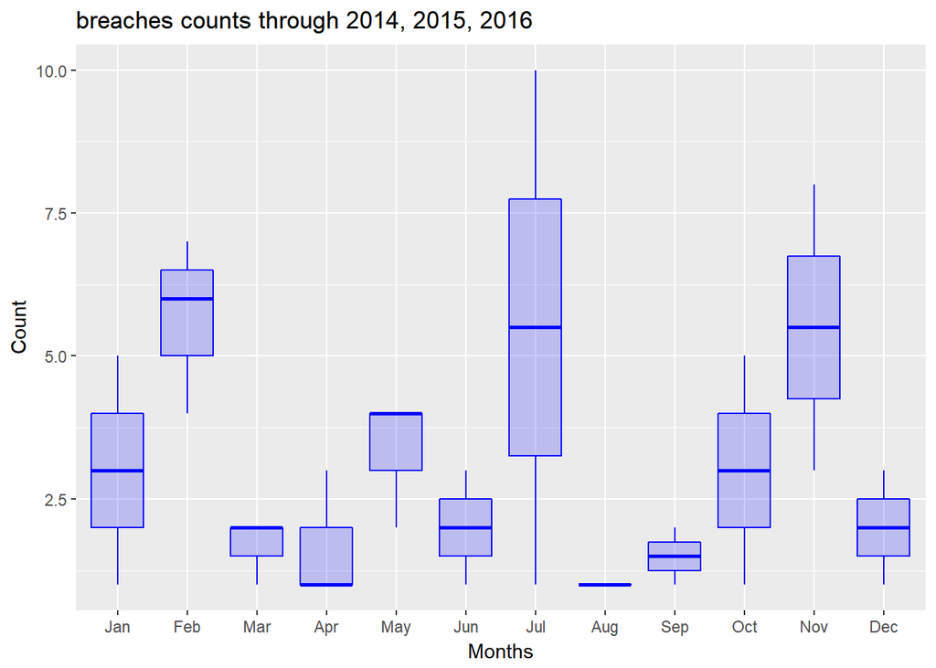

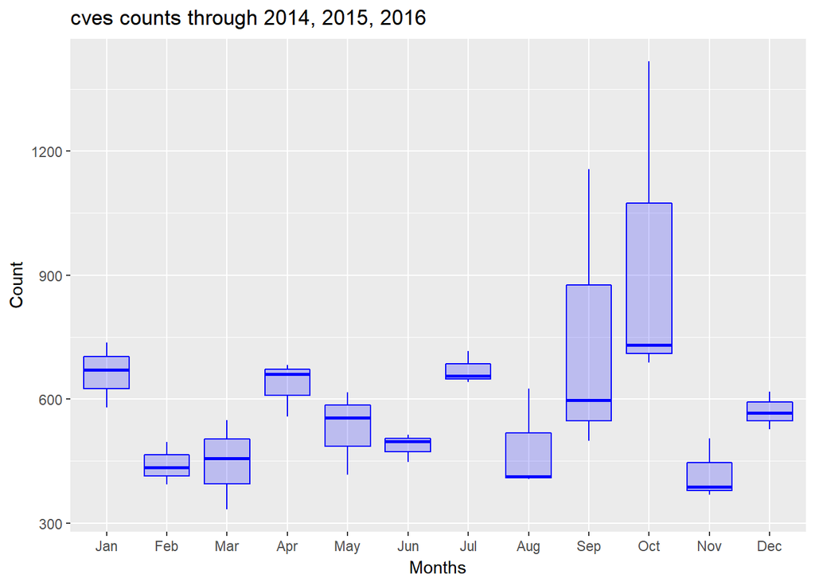